# 432: Lab 05

- Show All Code
- Hide All Code
- View Source

Author

Max Tjen

Published

2023-03-01

## 0.1 R Packages and Setup

```r
knitr::opts_chunk$set(comment = NA)

library(janitor)
library(knitr)
library(patchwork)
library(naniar)
library(forcats)
library(tableone)
library(tidyverse)

theme_set(theme_bw())
```

# 1 Question 1

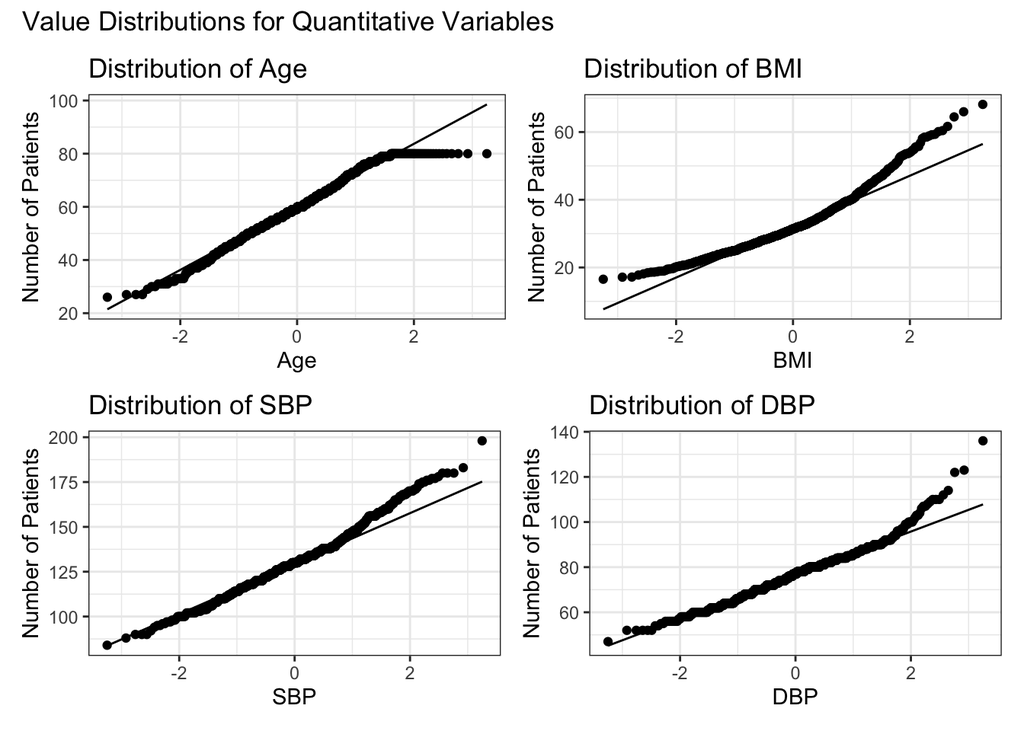

```r
# load and filter data
hbp <- read_csv("/Users/mtjen/Desktop/432/labs/lab02/hbp3456.csv",
                show_col_types = FALSE) |>
  mutate(bmi = weight / (height^2)) |>
  mutate(bmi_cat = factor(case_when(bmi > 0 & bmi < 18.5 ~ "Underweight",
                                    bmi >= 18.5 & bmi < 25 ~ "Healthy Weight",
                                    bmi >= 25 & bmi < 30 ~ "Overweight",
                                    bmi >= 30 ~ "Obesity"))) |>
  select(record, practice, age, race, eth_hisp,
         sex, insurance, bmi, bmi_cat, sbp, dbp) |>
  filter(practice == "Highland" | practice == "Sycamore") |>
  mutate(practice = as.factor(practice),
         race = as.factor(race),
         eth_hisp = as.factor(eth_hisp),
         sex = as.factor(sex),
         insurance = as.factor(insurance),
         race = fct_relevel(race, "AA_Black", "Asian", "White", "Other"),
         insurance = fct_relevel(insurance, "Uninsured", "Medicaid",
                                 "Medicare", "Commercial"),
         bmi_cat = fct_relevel(bmi_cat, "Underweight", "Healthy Weight",
                               "Overweight", "Obesity"))

# create QQ plots for quantitative variables to check normality
p1 <- ggplot(hbp, aes(sample = age)) +
  geom_qq() +
  geom_qq_line() +
  labs(title = "Distribution of Age",
       x = "Age",
       y = "Number of Patients")

p2 <- ggplot(hbp, aes(sample = bmi)) +
  geom_qq() +
  geom_qq_line() +
  labs(title = "Distribution of BMI",
       x = "BMI",
       y = "Number of Patients")

p3 <- ggplot(hbp, aes(sample = sbp)) +
  geom_qq() +
  geom_qq_line() +
  labs(title = "Distribution of SBP",
       x = "SBP",
       y = "Number of Patients")

p4 <- ggplot(hbp, aes(sample = dbp)) +
  geom_qq() +
  geom_qq_line() +
  labs(title = "Distribution of DBP",
       x = "DBP",
       y = "Number of Patients")

# display plots
(p1 + p2) / (p3 + p4) +
  plot_annotation(title = "Value Distributions for Quantitative Variables")
```

```r
# check NA values
miss_var_summary(hbp)
```

```
# A tibble: 11 × 3
   variable  n_miss pct_miss
   <chr>      <int>    <dbl>
 1 eth_hisp      34    3.94
 2 race          31    3.59
 3 bmi            7    0.810
 4 bmi_cat        7    0.810
 5 record         0    0
 6 practice       0    0
 7 age            0    0
 8 sex            0    0
 9 insurance      0    0
10 sbp            0    0
11 dbp            0    0
```

```r
# create table
vars <- c("age", "race", "eth_hisp", "sex", "insurance",
          "bmi", "bmi_cat", "sbp", "dbp")
factorVars <- c("race", "eth_hisp", "sex", "insurance", "bmi_cat")
trt <- c("practice")

table <- CreateTableOne(data = hbp,
                        vars = vars,
                        factorVars = factorVars,
                        strata = trt)

print(table,
      nonnormal = c("bmi"),
      exact = c("eth_hisp", "sex"))
```

```
                    Stratified by practice
                     Highland              Sycamore              p      test
  n                     432                   432
  age (mean (SD))     55.22 (11.35)         63.90 (11.34)        <0.001
  race (%)                                                       <0.001
     AA_Black            52 (12.0)            335 (83.5)
     Asian               12 ( 2.8)              3 ( 0.7)
     White              367 (85.0)             53 (13.2)
     Other                1 ( 0.2)             10 ( 2.5)
  eth_hisp = Yes (%)     93 (21.5)              0 ( 0.0)         <0.001 exact
  sex = M (%)           178 (41.2)            148 (34.3)          0.042 exact
  insurance (%)                                                  <0.001
     Uninsured           60 (13.9)              0 ( 0.0)
     Medicaid           161 (37.3)              0 ( 0.0)
     Medicare           137 (31.7)            192 (44.4)
     Commercial          74 (17.1)            240 (55.6)
  bmi (median [IQR])  31.94 [27.32, 37.71]  30.74 [26.81, 36.39]  0.064 nonnorm
  bmi_cat (%)                                                     0.250
     Underweight          4 ( 0.9)              2 ( 0.5)
     Healthy Weight      60 (14.1)             74 (17.1)
     Overweight         104 (24.5)            120 (27.8)
     Obesity            257 (60.5)            236 (54.6)
  sbp (mean (SD))    131.18 (18.20)        130.12 (15.99)         0.364
  dbp (mean (SD))     78.69 (10.24)         74.55 (10.67)        <0.001
```

- Missing Data by Variable: `practice` = 0, `age` = 0, `race` = 31, `eth_hisp` = 34, `sex` = 0, `insurance` = 0, `bmi` = 7, `bmi_cat` = 7, `sbp` = 0, `dbp` = 0
- `bmi` treated as non-normal since the value distribution is skewed right

From our table, we can see a couple of important statistics about subjects in the Highland and Sycamore practices. The first thing is the average age, as the average age of Sycamore subjects is about 8.5 years older than that of Highland. Another big thing is racial breakdown, as Sycamore subjects are predominantly African-American while Highland is predominantly White. Similarly, Highland has a decent amount of ethnically Hispanic subjects (93) relative to Sycamore, who has 0. One last thing to notice is the primary insurance breakdown, where Highland’s subjects are relatively diverse while Sycamore subjects only have Medicare or commercial insurance.

# 2 Question 2